# Demo For E-Learning Design

Ashish Gurung

2023-09-28

```r
# library(irr)
library(psych)
library(ggpubr)
library(broom)
```

GOAL: Start with the simple stuff. Once you have that you can build on your findings and do more complex analysis.

## What is inter-rater reliability?

1. Helps establish consistency/agreement.
2. Binary Classification

Types of Kappas:

Between Subjects (n=2): Cohen’s Kappa

Between Subjects (n>=2): Fleiss’ Kappa

#### Question before we proceed, What is the scale for Kappas: [0,1], [-1,1], [-inf, inf]

Why [-1,1]?

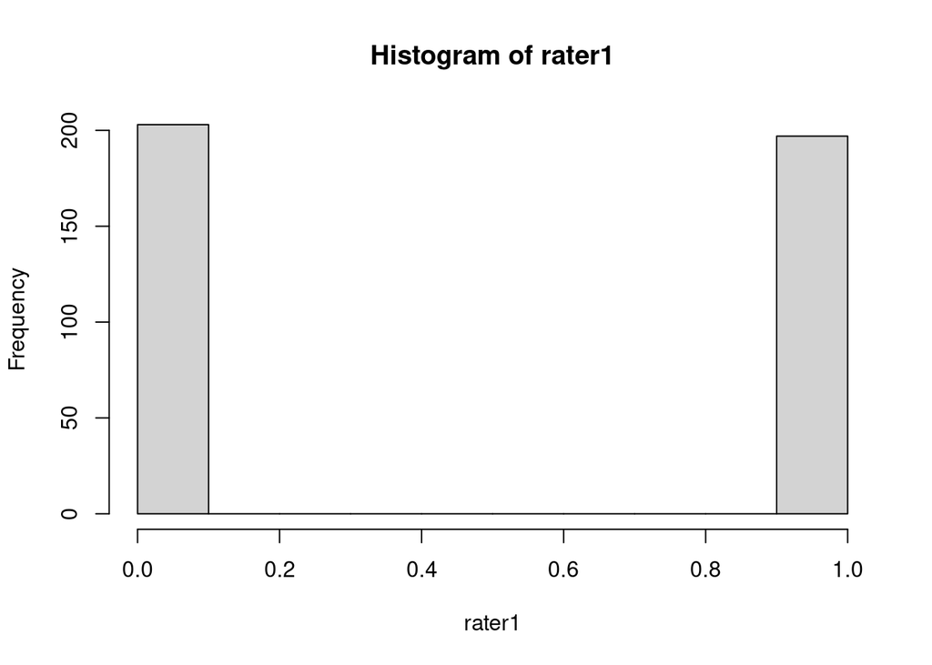

```r
rater1 <- rbinom(400, 1, 0.50)
hist(rater1)
```

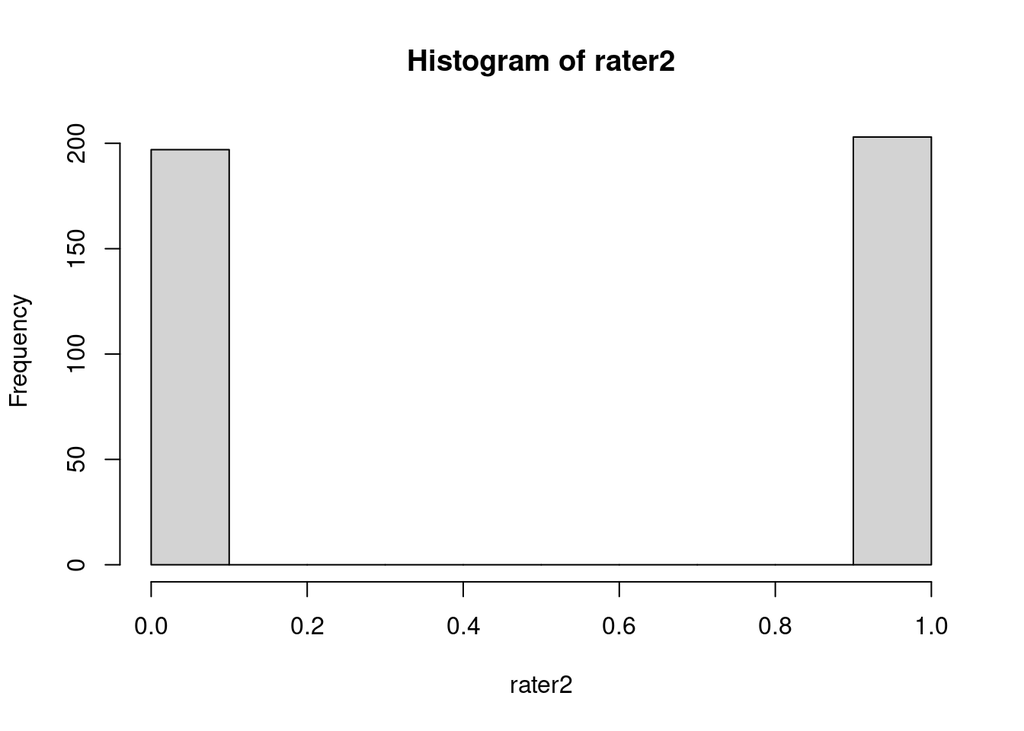

```r
rater2 <- rbinom(400, 1, 0.50)
hist(rater2)
```

#### Kappa on pure chance

```r
cohen.kappa(x=cbind(rater1, rater2))
```

```
## Call: cohen.kappa1(x = x, w = w, n.obs = n.obs, alpha = alpha, levels = levels)
##
## Cohen Kappa and Weighted Kappa correlation coefficients and confidence boundaries
##                   lower estimate upper
## unweighted kappa -0.088     0.01  0.11
## weighted kappa   -0.088     0.01  0.11
##
##  Number of subjects = 400
```

#### Kappa on perfect agreement

```r
df_irr <- data.frame(rater1)
df_irr$rater2 <- df_irr$rater1

cohen.kappa(x=cbind(df_irr$rater1, df_irr$rater2))
```

```
## Call: cohen.kappa1(x = x, w = w, n.obs = n.obs, alpha = alpha, levels = levels)
##
## Cohen Kappa and Weighted Kappa correlation coefficients and confidence boundaries
##                  lower estimate upper
## unweighted kappa     1        1     1
## weighted kappa       1        1     1
##
##  Number of subjects = 400
```

#### Kappa on perfect disagreement

```r
df_irr$rater3 <- df_irr$rater1
# table(df_irr$rater3)
df_irr$rater3 <- df_irr$rater3 - 1
# table(df_irr$rater3)
df_irr[df_irr$rater3 < 0, ]$rater3 <- 1
# table(df_irr$rater3)
cohen.kappa(x=cbind(df_irr$rater1, df_irr$rater3))
```

```
## Call: cohen.kappa1(x = x, w = w, n.obs = n.obs, alpha = alpha, levels = levels)
##
## Cohen Kappa and Weighted Kappa correlation coefficients and confidence boundaries
##                  lower estimate upper
## unweighted kappa    -1       -1 -0.99
## weighted kappa      -1       -1 -0.99
##
##  Number of subjects = 400
```

#### Kappa on 10% disagreement

```r
df_irr$rater4 <- df_irr$rater1

indices <- sample(1:400, 40, replace=FALSE)

# table(df_irr$rater4)
df_irr[indices, ]$rater4 <- df_irr[indices, ]$rater4 - 1
# table(df_irr$rater4)
df_irr[df_irr$rater4 < 0, ]$rater4 <- 1
# table(df_irr$rater4)

cohen.kappa(x=cbind(df_irr$rater1, df_irr$rater4))
```

```
## Call: cohen.kappa1(x = x, w = w, n.obs = n.obs, alpha = alpha, levels = levels)
##
## Cohen Kappa and Weighted Kappa correlation coefficients and confidence boundaries
##                  lower estimate upper
## unweighted kappa  0.74      0.8  0.86
## weighted kappa    0.74      0.8  0.86
##
##  Number of subjects = 400
```

1. What if the classification is not binary?
2. What does the weighted kappa mean?
   1. linear vs quadratic [reference materials](https://scikit-learn.org/stable/modules/generated/sklearn.metrics.cohen_kappa_score.html)

# Next we talk about randomization and Experiments.

## Randomization

Regular randomization: random sample of size 100 from the population sample size of 10000

```r
for (i in 1:10) {
  print(mean(sample(1:10000, 100, replace=FALSE)))
}
```

```
## [1] 4995.47
## [1] 5356.49
## [1] 4814.96
## [1] 4892.95
## [1] 5573.04
## [1] 5140.3
## [1] 5195.61
## [1] 5016.17
## [1] 4938.28
## [1] 4835.93
```

1. mean of means
2. 10 random sample of size 10 from the population sample size of 10000

```r
mean_of_means = 0
for (i in 1:10) {
  random_sample <- sample(1:10000, 10, replace=FALSE)
  sample_mean <- mean(random_sample)
  print(sample_mean)
  mean_of_means = mean_of_means + sample_mean
}
```

```
## [1] 4889.2
## [1] 4612.3
## [1] 5108.3
## [1] 6117.4
## [1] 4387.2
## [1] 4701.8
## [1] 4557.1
## [1] 4200.3
## [1] 4984.8
## [1] 5725.4
```

```r
print(mean_of_means/10)
```

```
## [1] 4928.38
```

## Experiments:

Why do experiments randomize?

1. Remove _____ (bias)  
   e.g. selection effect

### Intuition Check:

Introduce factorial design.

- How many factors are there in a (2 X 2) design?
- How many factors are there in a (2 X 3) design?
- How many factors are there in a (3 X 3) design?
- How many factors are there in a (2 X 2 X 2) design?

#### Example Research Question:

What is more important for sapling growth:

- **water or sunlight?**

|  |  | Sunlight |  |
| --- | --- | --- | --- |
|  |  | 0 | 1 |
| **Water** | 0 | no water no sunlight (00) | no water sunlight (01) |
|  | 1 | water no sunlight (10) | water and sunlight (11) |

What are the two factors here?

# Simulating data

```r
col_00 <- rnorm(400, mean = 20, sd=5)
col_01 <- rnorm(400, mean = 30, sd=8)
col_10 <- rnorm(400, mean = 24, sd=6)
col_11 <- rnorm(400, mean = 50, sd=12)

df_00 <- data.frame(height = col_00, water = "no_water", sun = "no_sunlight")
df_01 <- data.frame(height = col_01, water = "no_water", sun = "sunlight")
df_10 <- data.frame(height = col_10, water = "water", sun = "no_sunlight")
df_11 <- data.frame(height = col_11, water = "water", sun = "sunlight")
df_main <- rbind(df_00, df_01, df_10, df_11)
table(df_main$water, df_main$sun)
```

```
##
##            no_sunlight sunlight
##   no_water         400      400
##   water            400      400
```

```r
head(df_main)
```

```
##     height    water         sun
## 1 18.32342 no_water no_sunlight
## 2 19.72253 no_water no_sunlight
## 3 17.21578 no_water no_sunlight
## 4 21.40726 no_water no_sunlight
## 5 14.65320 no_water no_sunlight
## 6 32.82120 no_water no_sunlight
```

#### let us develop some intuition regarding the data

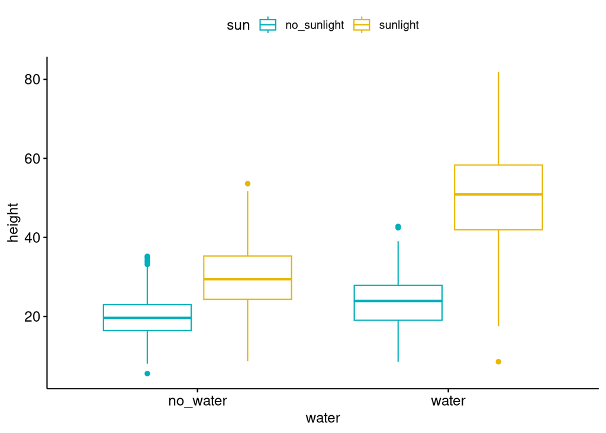

```r
ggboxplot(df_main, x='water', y='height', color='sun', palette = c("#00AFBB", "#E7B800"))
```

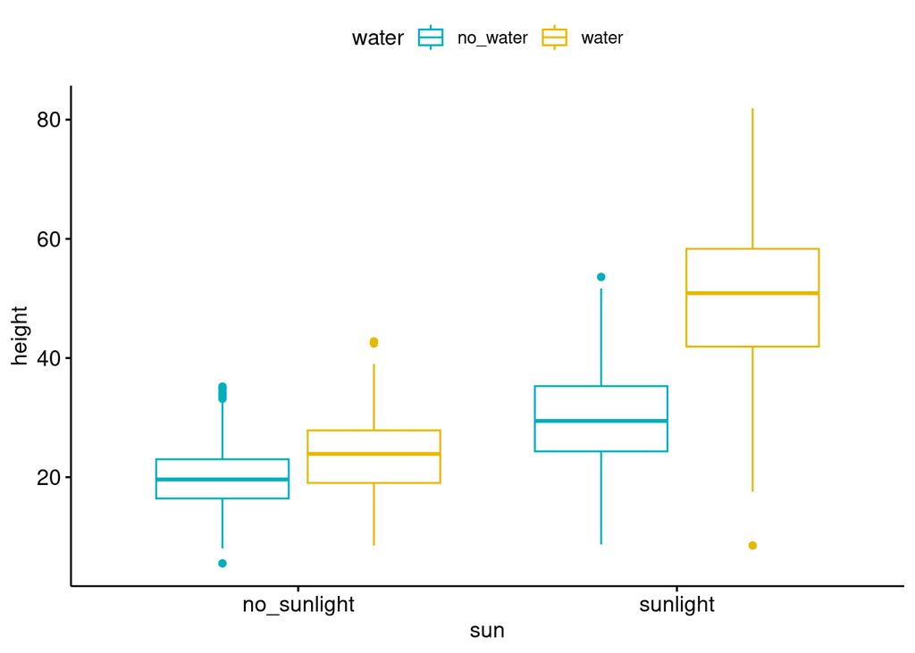

```r
ggboxplot(df_main, x='sun', y='height', color='water', palette = c("#00AFBB", "#E7B800"))
```

## Main Effects

let’s do a t-test to verify our intuition regarding the main effects:

#### water:

```r
t.test(df_main[df_main$water == 'no_water',]$height, df_main[df_main$water == 'water',]$height, alternative = "two.sided", var.equal = FALSE)
```

```
##
##  Welch Two Sample t-test
##
## data:  df_main[df_main$water == "no_water", ]$height and df_main[df_main$water == "water", ]$height
## t = -18.264, df = 1207, p-value < 2.2e-16
## alternative hypothesis: true difference in means is not equal to 0
## 95 percent confidence interval:
##  -13.19754 -10.63714
## sample estimates:
## mean of x mean of y
##  24.90011  36.81745
```

#### sunlight:

```r
t.test(df_main[df_main$sun == 'no_sunlight',]$height, df_main[df_main$sun == 'sunlight',]$height, alternative = "two.sided", var.equal = FALSE)
```

```
##
##  Welch Two Sample t-test
##
## data:  df_main[df_main$sun == "no_sunlight", ]$height and df_main[df_main$sun == "sunlight", ]$height
## t = -33.043, df = 1057.6, p-value < 2.2e-16
## alternative hypothesis: true difference in means is not equal to 0
## 95 percent confidence interval:
##  -19.35614 -17.18613
## sample estimates:
## mean of x mean of y
##  21.72322  39.99435
```

#### ANOVA:

```r
two_factor_anova <- aov( height ~ sun + water, data = df_main)
summary(two_factor_anova)
```

```
##               Df Sum Sq Mean Sq F value Pr(>F)
## sun            1 133534  133534  1538.3 <2e-16 ***
## water          1  56809   56809   654.4 <2e-16 ***
## Residuals   1597 138628      87
## ---
## Signif. codes:  0 '***' 0.001 '**' 0.01 '*' 0.05 '.' 0.1 ' ' 1
```

#### What does this tell us?

1. The main effect of exposure to sunlight is significant
2. The main effect of exposure to water is significant

```r
model.tables(two_factor_anova, type = "means", se=TRUE)
```

```
## Tables of means
## Grand mean
##
## 30.85878
##
##  sun
## sun
## no_sunlight    sunlight
##       21.72       39.99
##
##  water
## water
## no_water    water
##    24.90    36.82
##
## Standard errors for differences of means
##            sun  water
##         0.4658 0.4658
## replic.    800    800
```

### Tukey Honest Significant Difference

Effect sizes for Main Effects:

```r
tidy(TukeyHSD(two_factor_anova))
```

```
## # A tibble: 2 × 7
##   term  contrast             null.value estimate conf.low conf.high adj.p.value
##   <chr> <chr>                     <dbl>    <dbl>    <dbl>     <dbl>       <dbl>
## 1 sun   sunlight-no_sunlight          0     18.3     17.4      19.2           0
## 2 water water-no_water                0     11.9     11.0      12.8           0
```

## Interaction and Sub Effects

let’s also explore sub-effects:

#### ANOVA with interaction:

```r
two_factor_anova_interaction <- aov( height ~ sun + water + sun:water, data = df_main)
summary(two_factor_anova_interaction)
```

```
##               Df Sum Sq Mean Sq F value Pr(>F)
## sun            1 133534  133534  1915.6 <2e-16 ***
## water          1  56809   56809   814.9 <2e-16 ***
## sun:water      1  27371   27371   392.6 <2e-16 ***
## Residuals   1596 111257      70
## ---
## Signif. codes:  0 '***' 0.001 '**' 0.01 '*' 0.05 '.' 0.1 ' ' 1
```

#### What does this tell us?

1. The main effect of exposure to sunlight is significant
2. The main effect of exposure to water is significant
3. the effect of sunlight varies with the effect of water and vice-versa

```r
model.tables(two_factor_anova_interaction, type = "means", se=TRUE)
```

```
## Tables of means
## Grand mean
##
## 30.85878
##
##  sun
## sun
## no_sunlight    sunlight
##       21.72       39.99
##
##  water
## water
## no_water    water
##    24.90    36.82
##
##  sun:water
##              water
## sun           no_water water
##   no_sunlight 19.90    23.55
##   sunlight    29.90    50.09
##
## Standard errors for differences of means
##            sun  water sun:water
##         0.4175 0.4175    0.5904
## replic.    800    800       400
```

### Tukey Honest Significant Difference

Effect sizes for Main and Sub Effects:

```r
tidy(TukeyHSD(two_factor_anova_interaction))
```

```
## # A tibble: 8 × 7
##   term      contrast          null.value estimate conf.low conf.high adj.p.value
##   <chr>     <chr>                  <dbl>    <dbl>    <dbl>     <dbl>       <dbl>
## 1 sun       sunlight-no_sunl…          0    18.3     17.5      19.1      0
## 2 water     water-no_water             0    11.9     11.1      12.7      0
## 3 sun:water sunlight:no_wate…          0    10.0      8.48     11.5      0
## 4 sun:water no_sunlight:wate…          0     3.65     2.13      5.16     5.04e-9
## 5 sun:water sunlight:water-n…          0    30.2     28.7      31.7      0
## 6 sun:water no_sunlight:wate…          0    -6.35    -7.87     -4.84     0
## 7 sun:water sunlight:water-s…          0    20.2     18.7      21.7      0
## 8 sun:water sunlight:water-n…          0    26.5     25.0      28.1      0
```

### Bonus Points:

```r
# what if you knew the average height of the parent tree of the sapling
# conduct a ANCOVA

# aov(height ~ sun + water + sun:water + parent_tree_height, data = df_main)
```